# Manual for CARMA-X

Zikun Yang

2025-01-02

### Introduction

CARMA-X is an innovative fine-mapping method designed specifically for admixed populations, which often face unique challenges in genetic studies due to their complex ancestry structure. Admixed individuals combine genetic material from multiple ancestral backgrounds, creating linkage disequilibrium (LD) patterns that differ significantly from single-ancestry populations. Existing fine-mapping methods typically struggle to accurately identify causal variants in such settings, as they do not account for *cross-ancestry correlations* and may rely on *limited or non-representative reference panels*.

CARMA-X addresses these limitations by incorporating the following features:

- *Novel LD estimation* that adjusts for complex LD patterns in admixed populations
- *Robust Bayesian hypothesis testing* to detect and correct for LD discrepancies
- *Adaptability to small, cross-ancestry reference panels* for broader applicability
- *Prioritization of putative causal variants* that reflect *ancestry-specific effects*, enhancing fine-mapping accuracy

The CARMA-X package provides a user-friendly R interface for implementing this method, offering a powerful tool for researchers focused on expanding genetic insights beyond European populations. The package and code are accessible at [CARMAX GitHub](https://github.com/ZikunY/CARMAX).

### Implementation of CARMA-X

To get started with CARMA-X, follow these steps to install the package and access the example dataset included in the repository.

#### Install the CARMA-X Package

Install CARMA-X directly from GitHub using the `devtools` package. This will allow you to download and install the latest version of CARMA-X.

```r
# Install CARMA-X from GitHub
devtools::install_github("ZikunY/CARMAX")
# Load the CARMA-X package
library(CARMAX)
```

#### Clone the Repository (Optional)

For a hands-on learning experience, you can use the example dataset provided in the CARMA-X repository. This dataset allows you to practice and explore CARMA-X’s capabilities in fine-mapping for admixed populations.

To clone the repository, open your command line interface (CLI) and enter the following command:

```bash
git clone https://github.com/ZikunY/CARMAX.git
```

After cloning, navigate to the `CARMAX` directory, where you’ll find the example dataset under the `data/` folder. You can load this data into R to try out CARMA-X functions and see how it performs on real data.

### Demonstration of CARMA-X

In this section, we’ll walk through a demonstration of CARMA-X using an example dataset included in the repository. This dataset is derived from the simulation study described in our paper, designed specifically to evaluate CARMA-X’s performance in fine-mapping within admixed populations.

#### Details on the Simulation Study

The example dataset was simulated with the following steps:

1. **Genotype Data Generation**: Genotype data was extracted using admixed individuals with both African (AFR) and European (EUR) ancestries, sourced from the UK Biobank. Each individual has genome-wide ancestries greater than 40% for both AFR and EUR. We derived the ancestry-specific genotypes by:
   - Phasing the genotypes
   - Applying local ancestry inference (LAI).
2. **Selection of Causal Variants**: Causal variants were selected based on LD threshold criterion to ensure selected variants maintained a manageable LD structure. This criterion helped replicate the conditions of fine-mapping as seen in practical GWAS applications.
3. **Phenotype Simulation**: Phenotypes were simulated using a linear regression model incorporating ancestry-specific effects for each causal variant. The model used was:

   $$y = X_{AFR} \cdot \beta_{AFR} + X_{EUR} \cdot \beta_{EUR} + \epsilon$$

   where $\beta_{AFR}$ and $\beta_{EUR}$ represent effect sizes for AFR and EUR ancestries, $X_{AFR}$ and $X_{EUR}$ denote the deconvoluted genotype matrices for AFR and EUR ancestries based on the LAI results. The effect sizes were drawn from a multivariate normal distribution to:
   - Simulate varying effect size correlations across ancestries.
   - Introduce realistic diversity in effect scenarios.

The cross-ancestry correlation of effect sizes in the example dataset is set at 0.25.

4. **Summary Statistics Calculation**: Using the simulated phenotypes, ancestry-specific summary statistics ($Z_{AFR}$ and $Z_{EUR}$) were calculated to provide input data for CARMA-X’s fine-mapping functions.
5. **Using LD from Reference Panels**: In cases where individual-level data is not available, CARMA-X employs external LD matrices from reference panels. Here, we utilized 1000 Genomes Project data, selecting individuals from the AFR (n = 661) and EUR (n = 503) populations to construct ancestry-specific LD matrices, which are used by CARMA-X subsequentilally in this document.

This example dataset represents a practical use-case scenario for CARMA-X, reflecting the diverse LD and ancestry-specific effect patterns found in real-world data. For more details of the simulation process, please check the paper on CARMA-X.

#### Load the Example Data

We begin by loading the example dataset, an RDS file containing summary statistics of the admixed population and genotype data for two ancestry groups: AFR and EUR.

```r
# Load the dataset
dt <- readRDS('./CARMAX/Example/Example.rds')
```

#### Read Summary Statistics

We then extract the summary statistics data from the loaded dataset. The `dt$Summ data` dataset includes information on variants, such as the estimated effect size, standard deviation, and the corresponding summary statistics for EUR and AFR ancestries. The first few rows of `dt$Summ data` are displayed below.

```r
# Extract summary statistics data
summ <- dt$`Summ data`
head(summ)
```

```
##   CHROM      POS REF ALT     BETA_AFR     SE_AFR      Z_AFR    BETA_EUR
## 1    18 44319839   G   A -0.010337835 0.01825949 -0.5661624 -0.04218797
## 2    18 44320960   G   A -0.007964191 0.01825988 -0.4361578 -0.03979042
## 3    18 44320999   G   T -0.007964191 0.01825988 -0.4361578 -0.03979042
## 4    18 44321959   G   A  0.032208608 0.01825099  1.7647597 -0.05054498
## 5    18 44322532   C   T -0.014223141 0.01825862 -0.7789825 -0.04346205
## 6    18 44322703   C   G  0.076370192 0.01820713  4.1945204 -0.06928450
##       SE_EUR     Z_EUR
## 1 0.01824420 -2.312404
## 2 0.01824600 -2.180775
## 3 0.01824600 -2.180775
## 4 0.01823712 -2.771544
## 5 0.01824321 -2.382369
## 6 0.01821658 -3.803376
```

The figures below visualize the summary statistics for EUR and AFR ancestries. The causal variant associated with the simulated phenotype is highlighted with red bullets in the plots.

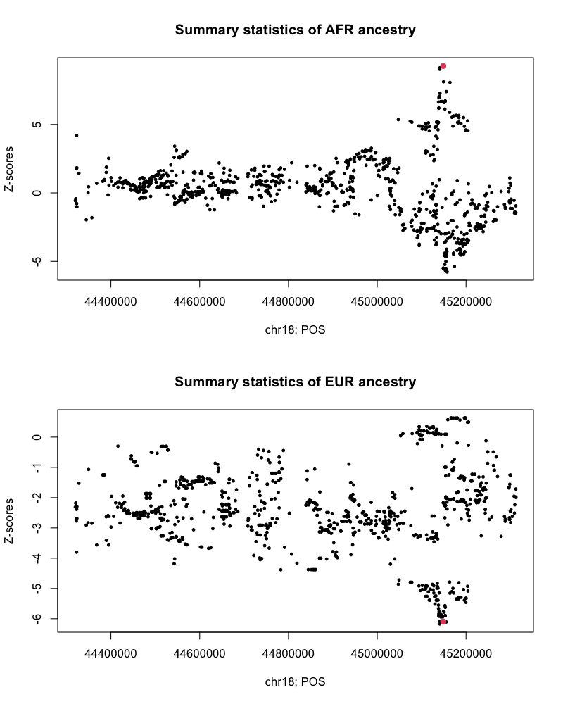

#### Initialize Lists for Z-Scores, LD Matrices, and Other Parameters

Next, we create lists to store Z-scores (`z.list`), LD matrices (`ld.list`), lambda values (`lambda.list`), and other parameters required for CARMA-X.

```r
# Initialize lists
lambda.power <- 1
z.list <- list()
ld.list <- list()
full.w.list <- list()
lambda.list <- c()
label.list <- list()
input.prior.list <- list()
# Read the Z-scores
# AFR ancestry
g <- 1
z.list[[g]] <- as.matrix(summ$`Z_AFR`)
lambda.list[[g]] <- lambda.power

# EUR ancestry
g <- 2
z.list[[g]] <- as.matrix(summ$`Z_EUR`)
lambda.list[[g]] <- lambda.power
```

Using the genotype data (`dt$AFR genotype` and `dt$EUR genotype`) provided in the example dataset, we compute LD matrices for the AFR and EUR ancestries of the admixed population. This is essential for fine-mapping and modeling ancestry-specific correlations.

```r
#Compute the LD for each ancestry
ld.list[[1]] <- cor(dt$`AFR genotype`)
ld.list[[2]] <- cor(dt$`EUR genotype`)
```

#### Define the Prior Distribution

We define the prior distribution to be used in the CARMA-X algorithm. Here, we select the `Spike-slab` prior, which is commonly used in Bayesian variable selection to allow sparse effects.

```r
# Define the prior distribution
prior.name <- 'Spike-slab'
```

#### Run CARMA-X

Finally, we run the CARMA-X function with the prepared data and parameters. A random seed can be set for reproducibility. Since we are estimating the LD of an admixed cohort using homogeneous ancestral cohorts from AFR and EUR, we set the `LD.estimation` option to `TRUE`. Additionally, we enable `outlier.switch = TRUE` because we are using the reference panel for LD estimation.

```r
# Set a random seed
set.seed(123)
# Run CARMA-X
results <- CARMAX(z.list, ld.list, lambda.list = lambda.list, effect.size.prior = prior.name, LD.estimation = TRUE, outlier.switch = TRUE)
```

### Analyze and Interpret Results

In this section, we examine and interpret the results from running CARMA-X on the example dataset. The `results` object contains key outputs from the fine-mapping analysis, including information on likely causal variants across the AFR and EUR ancestries.

#### View the Summary of Results

We begin by inspecting the `results` object, which provides essential information for each variant identified in the analysis. The following code lists the four essential components included in the CARMA-X results.

```r
names(results[[1]])
```

```
## [1] "PIPs"           "Credible set"   "Credible model" "Outliers"
```

The main components of the results object are:

1. **`PIPs`**: The posterior inclusion probabilities (PIPs) for each variant, representing the likelihood of each variant being causal.
2. **`Credible set`**: The variants included in CARMA-X’s credible set. These variants meet both the cumulative PIP threshold (e.g., 95%) and exhibit a high degree of LD correlation with one another.
3. **`Credible model`**: The most probable models or configurations with the largest posterior probabilities, highlighting possible variant combinations that could explain the observed associations.
4. **`Outliers`**: Variants identified as outliers through the Bayesian hypothesis testing implemented in CARMA-X, which are flagged due to deviation from expected LD patterns.

The `results` variable thus provides critical insights into posterior probabilities, credible sets, and other key metrics for each variant.

#### Identify and Visualize Top Causal Variants

To identify the top causal variants, we focus on the variants included in CARMA-X’s credible set. This approach ensures that the credible set includes a subset of variants most likely to contain the true causal variant(s), considering both statistical confidence and genetic correlation.

```r
# Extract the credible set variants from summary statistics and sort them
cs <- summ[sort(results[[1]]$`Credible set`[[2]][[1]]), ]

# Loop through each credible set and annotate the PIP and credible set number
for(cs.num in 1:length(results[[1]]$`Credible set`[[2]])) {
  # Assign posterior inclusion probabilities (PIP) to each variant in the credible set
  cs$PIP <- results[[1]]$PIPs[sort(results[[1]]$`Credible set`[[2]][[cs.num]])]

  # Annotate each variant with its credible set number
  cs$CS <- cs.num
}

# Display the annotated credible set
print(cs)
```

```
##     CHROM      POS REF ALT  BETA_AFR     SE_AFR    Z_AFR   BETA_EUR     SE_EUR
## 789    18 45140759   G   A 0.1628062 0.01801683 9.036339 -0.1120250 0.01814552
## 790    18 45141069   G   T 0.1646027 0.01801139 9.138812 -0.1105479 0.01814854
## 799    18 45148741   T   G 0.1669523 0.01800418 9.272975 -0.1105479 0.01814854
##         Z_EUR        PIP CS
## 789 -6.173699 0.03023337  1
## 790 -6.091284 0.27325561  1
## 799 -6.091284 0.69730187  1
```

As shown in the table, the credible set of CARMA-X successfully captures variants with substantial Z-scores that are highly correlated within the set. Notably, the causal variant, identified as `chr18 45148741 T G`, is included in the CARMA-X credible set and received the highest PIP from CARMA-X.

#### Visualize PIPs

A common approach to visualizing fine-mapping results is to plot the PIPs of the variants, which helps in assessing the evidence for causality across different loci highlights key variants.

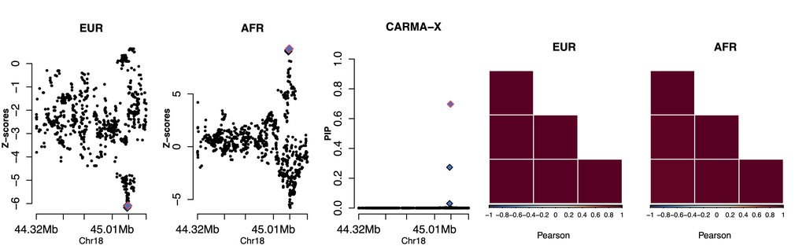

The figure displays the summary statistics for EUR and AFR ancestries in the left two panels, the PIPs calculated by CARMA-X in the middle panel, and the ancestral LD of variants within the credible sets in the right two panels. Variants identified by CARMA-X’s credible set are highlighted as blue diamonds, with the causal variant further marked by a red frame. This visualization effectively emphasizes variants with strong evidence for association with the phenotype, enabling researchers to focus on the most promising candidates across ancestries.

### Conclusion

This analysis provides a comprehensive overview of how CARMA-X identifies and visualizes causal variants, enabling insights into the genetic architecture of complex traits in admixed populations.